# Build Final Model: LCIA QSAR Project

**Date:** May 19, 2023

This notebook accomplishes the following objectives:

1. Select a single workflow for predicting oral points of departure of chemicals for "general" effects
1. According to this workflow, build a final model to make predictions for chemicals that were unseen during training

```python
from os import path
from sklearn.ensemble import RandomForestRegressor
from sklearn import metrics

import configuration as config
from workflow_lcia import LciaQsarModelingWorkflow
# Enable modules to be imported from the parent directory.
import sys
sys.path.append('..')
from common.input_output import combine_csv_files
from common.workflow_base import select_features
from common import plot
```

## Load the data

```python
workflow_data = combine_csv_files(
    config.data_path_components_mapper,
    index_col=0
)

workflow_data
```

| DTXSID | comptox AVERAGE_MASS | comptox 48HR_DAPHNIA_LC50_MOL/L_TEST_PRED | comptox DENSITY_G/CM^3_TEST_PRED | comptox DEVTOX_TEST_PRED | comptox 96HR_FATHEAD_MINNOW_MOL/L_TEST_PRED | comptox FLASH_POINT_DEGC_TEST_PRED | comptox AMES_MUTAGENICITY_TEST_PRED | comptox ORAL_RAT_LD50_MOL/KG_TEST_PRED | comptox SURFACE_TENSION_DYN/CM_TEST_PRED | comptox THERMAL_CONDUCTIVITY_MW/(M*K)_TEST_PRED | ... | opera CERAPP_Bind_pred | opera CoMPARA_Ago_pred | opera CoMPARA_Anta_pred | opera CoMPARA_Bind_pred | opera CATMoS_LD50_pred | opera FUB_pred | opera Clint_pred | opera CACO2_pred | ld50_experimental median_LD50 | oral log10_POD_[mg/kg-d] |
| --- | --- | --- | --- | --- | --- | --- | --- | --- | --- | --- | --- | --- | --- | --- | --- | --- | --- | --- | --- | --- | --- |
| DTXSID5020281 | 157.550 | 0.000108 | 1.372 | 0.323 | 0.000057 | 109.227 | 0.966 | 0.007079 | NaN | 137.950 | ... | 0 | 0.0 | 0.0 | 0 | 236.0 | 0.20 | 399.37 | -4.81 | 138.120754 | -1.098677 |
| DTXSID8020961 | 138.126 | 0.000065 | 1.309 | 0.250 | 0.000439 | 141.229 | 0.642 | 0.009141 | NaN | 162.043 | ... | 0 | 0.0 | 0.0 | 0 | 787.0 | 0.33 | 23.59 | -4.82 | 126.969502 | -0.231734 |
| DTXSID7030698 | 972.846 | NaN | 2.278 | NaN | NaN | 458.744 | 0.056 | NaN | NaN | NaN | ... | 0 | 0.0 | 0.0 | 0 | 9819.0 | 0.93 | 22.56 | -6.84 | 1728.603923 | 3.472003 |
| DTXSID2026652 | 162.276 | 0.000007 | 0.846 | 0.724 | 0.000018 | 71.527 | NaN | 0.029444 | 28.625 | 121.380 | ... | 0 | 0.0 | 0.0 | 0 | 2985.0 | 0.02 | 13.36 | -4.69 | 782.276836 | 1.042817 |
| DTXSID6026080 | 166.132 | 0.000640 | 1.482 | 0.405 | 0.000156 | 204.940 | 0.358 | 0.023550 | NaN | NaN | ... | 0 | 0.0 | 0.0 | 0 | 2860.0 | 0.28 | 0.00 | -5.11 | 1222.307556 | 1.842616 |
| ... | ... | ... | ... | ... | ... | ... | ... | ... | ... | ... | ... | ... | ... | ... | ... | ... | ... | ... | ... | ... | ... |
| DTXSID3026645 | 134.222 | 0.000025 | 0.868 | 0.668 | 0.000082 | 54.867 | NaN | 0.023281 | 28.026 | 123.106 | ... | 0 | 0.0 | 0.0 | 0 | 2893.0 | 0.08 | 9.15 | -4.61 | 953.086430 | 1.871706 |
| DTXSID0029133 | 136.150 | 0.000092 | 1.176 | 0.427 | 0.000261 | 102.496 | 0.105 | 0.007798 | 40.167 | 151.682 | ... | 1 | 0.0 | 0.0 | 0 | 1346.0 | 0.28 | 30.50 | -4.68 | 547.593785 | 1.215825 |
| DTXSID0021832 | 135.210 | 0.000043 | 0.930 | 0.580 | 0.000328 | 73.437 | 0.375 | 0.004457 | 32.059 | 136.205 | ... | 0 | 0.0 | 0.0 | 0 | 986.0 | 0.06 | 20.36 | -4.45 | 239.572281 | 0.799742 |
| DTXSID6020303 | 158.070 | NaN | NaN | 0.793 | NaN | NaN | 0.218 | NaN | NaN | NaN | ... | 0 | 0.0 | 0.0 | 0 | 233.0 | 0.77 | 34.96 | -5.14 | 88.000079 | 0.581300 |
| DTXSID5023792 | 137.138 | 0.000104 | 1.200 | 0.435 | 0.000192 | 102.856 | 0.609 | 0.008851 | NaN | 141.028 | ... | 0 | 0.0 | 0.0 | 0 | 1185.0 | 0.27 | 19.37 | -4.82 | 524.125480 | 0.957466 |

1396 rows × 36 columns

## Instantiate a "workflow" object

As we expand our original analysis, I created an interface which uses object-oriented programming design to make the analysis framework more scalable and extensible. The following is a brief overview of the general interface (preliminary, open to feedback).

A "workflow" object is like a factory for creating and evaluating different pipelines for supervised machine learning, in this case, for QSAR modeling. A workflow has the following components:

1. `data` from which different features and target variables can be defined for learning
2. `instructions` for getting a specific set of features (X) and target variable (y)
3. `estimator` for learning parameters from X & y and making predictions
4. `methods` (functions) for implementing cross-validation schemes, feature selection, and ultimately building a final model for deployment

```python
workflow = LciaQsarModelingWorkflow(
    workflow_data,
    config.get_features_for_source,
    config.ld50_pred_column_for_source,
    config.use_experimental_for_ld50,
    config.get_ld50_experimental,
    config.drop_missing_for_condition,
    config.pre_steps_for_condition,
    config.features_to_exclude_from
)
```

### Workflow has a "view" of all the data

```python
workflow._data
```

| DTXSID | comptox AVERAGE_MASS | comptox 48HR_DAPHNIA_LC50_MOL/L_TEST_PRED | comptox DENSITY_G/CM^3_TEST_PRED | comptox DEVTOX_TEST_PRED | comptox 96HR_FATHEAD_MINNOW_MOL/L_TEST_PRED | comptox FLASH_POINT_DEGC_TEST_PRED | comptox AMES_MUTAGENICITY_TEST_PRED | comptox ORAL_RAT_LD50_MOL/KG_TEST_PRED | comptox SURFACE_TENSION_DYN/CM_TEST_PRED | comptox THERMAL_CONDUCTIVITY_MW/(M*K)_TEST_PRED | ... | opera CERAPP_Bind_pred | opera CoMPARA_Ago_pred | opera CoMPARA_Anta_pred | opera CoMPARA_Bind_pred | opera CATMoS_LD50_pred | opera FUB_pred | opera Clint_pred | opera CACO2_pred | ld50_experimental median_LD50 | oral log10_POD_[mg/kg-d] |
| --- | --- | --- | --- | --- | --- | --- | --- | --- | --- | --- | --- | --- | --- | --- | --- | --- | --- | --- | --- | --- | --- |
| DTXSID5020281 | 157.550 | 0.000108 | 1.372 | 0.323 | 0.000057 | 109.227 | 0.966 | 0.007079 | NaN | 137.950 | ... | 0 | 0.0 | 0.0 | 0 | 236.0 | 0.20 | 399.37 | -4.81 | 138.120754 | -1.098677 |
| DTXSID8020961 | 138.126 | 0.000065 | 1.309 | 0.250 | 0.000439 | 141.229 | 0.642 | 0.009141 | NaN | 162.043 | ... | 0 | 0.0 | 0.0 | 0 | 787.0 | 0.33 | 23.59 | -4.82 | 126.969502 | -0.231734 |
| DTXSID7030698 | 972.846 | NaN | 2.278 | NaN | NaN | 458.744 | 0.056 | NaN | NaN | NaN | ... | 0 | 0.0 | 0.0 | 0 | 9819.0 | 0.93 | 22.56 | -6.84 | 1728.603923 | 3.472003 |
| DTXSID2026652 | 162.276 | 0.000007 | 0.846 | 0.724 | 0.000018 | 71.527 | NaN | 0.029444 | 28.625 | 121.380 | ... | 0 | 0.0 | 0.0 | 0 | 2985.0 | 0.02 | 13.36 | -4.69 | 782.276836 | 1.042817 |
| DTXSID6026080 | 166.132 | 0.000640 | 1.482 | 0.405 | 0.000156 | 204.940 | 0.358 | 0.023550 | NaN | NaN | ... | 0 | 0.0 | 0.0 | 0 | 2860.0 | 0.28 | 0.00 | -5.11 | 1222.307556 | 1.842616 |
| ... | ... | ... | ... | ... | ... | ... | ... | ... | ... | ... | ... | ... | ... | ... | ... | ... | ... | ... | ... | ... | ... |
| DTXSID3026645 | 134.222 | 0.000025 | 0.868 | 0.668 | 0.000082 | 54.867 | NaN | 0.023281 | 28.026 | 123.106 | ... | 0 | 0.0 | 0.0 | 0 | 2893.0 | 0.08 | 9.15 | -4.61 | 953.086430 | 1.871706 |
| DTXSID0029133 | 136.150 | 0.000092 | 1.176 | 0.427 | 0.000261 | 102.496 | 0.105 | 0.007798 | 40.167 | 151.682 | ... | 1 | 0.0 | 0.0 | 0 | 1346.0 | 0.28 | 30.50 | -4.68 | 547.593785 | 1.215825 |
| DTXSID0021832 | 135.210 | 0.000043 | 0.930 | 0.580 | 0.000328 | 73.437 | 0.375 | 0.004457 | 32.059 | 136.205 | ... | 0 | 0.0 | 0.0 | 0 | 986.0 | 0.06 | 20.36 | -4.45 | 239.572281 | 0.799742 |
| DTXSID6020303 | 158.070 | NaN | NaN | 0.793 | NaN | NaN | 0.218 | NaN | NaN | NaN | ... | 0 | 0.0 | 0.0 | 0 | 233.0 | 0.77 | 34.96 | -5.14 | 88.000079 | 0.581300 |
| DTXSID5023792 | 137.138 | 0.000104 | 1.200 | 0.435 | 0.000192 | 102.856 | 0.609 | 0.008851 | NaN | 141.028 | ... | 0 | 0.0 | 0.0 | 0 | 1185.0 | 0.27 | 19.37 | -4.82 | 524.125480 | 0.957466 |

1396 rows × 36 columns

### We provide instructions for getting specific features (X) & target (y) for evaluation

```python
target_column = ('oral', 'log10_POD_[mg/kg-d]')
data_source = 'comptox'
ld50_type = 'experimental'
data_condition = 'missing'
estimator = RandomForestRegressor(
    random_state=config.RANDOM_STATE_ESTIMATOR,
    n_jobs=config.N_JOBS
)

workflow.set_workflow_attributes(
    target_column,
    data_source,
    ld50_type,
    data_condition,
    estimator
)
```

### The workflow's attributes are defined accordingly

```python
workflow.X
```

| DTXSID | AVERAGE_MASS | 48HR_DAPHNIA_LC50_MOL/L_TEST_PRED | DENSITY_G/CM^3_TEST_PRED | DEVTOX_TEST_PRED | 96HR_FATHEAD_MINNOW_MOL/L_TEST_PRED | FLASH_POINT_DEGC_TEST_PRED | AMES_MUTAGENICITY_TEST_PRED | SURFACE_TENSION_DYN/CM_TEST_PRED | THERMAL_CONDUCTIVITY_MW/(M*K)_TEST_PRED | TETRAHYMENA_PYRIFORMIS_IGC50_MOL/L_TEST_PRED | ... | BOILING_POINT_DEGC_OPERA_PRED | HENRYS_LAW_ATM-M3/MOLE_OPERA_PRED | OPERA_KM_DAYS_OPERA_PRED | OCTANOL_AIR_PARTITION_COEFF_KOA_OPERA_PRED | SOIL_ADSORPTION_COEFFICIENT_KOC_L/KG_OPERA_PRED | OCTANOL_WATER_PARTITION_P_OPERA_PRED | MELTING_POINT_DEGC_OPERA_PRED | VAPOR_PRESSURE_MMHG_OPERA_PRED | WATER_SOLUBILITY_MOL/L_OPERA_PRED | median_LD50 |
| --- | --- | --- | --- | --- | --- | --- | --- | --- | --- | --- | --- | --- | --- | --- | --- | --- | --- | --- | --- | --- | --- |
| DTXSID5020281 | 157.550 | 0.000108 | 1.372 | 0.323 | 0.000057 | 109.227 | 0.966 | NaN | 137.950 | 0.000179 | ... | 242.0500 | 4.947790e-06 | 0.332365 | 2.124320e+04 | 507.6930 | 246.342872 | 82.9942 | 2.203470e-02 | 0.001318 | 138.120754 |
| DTXSID8020961 | 138.126 | 0.000065 | 1.309 | 0.250 | 0.000439 | 141.229 | 0.642 | NaN | 162.043 | 0.000520 | ... | 331.6720 | 1.265030e-09 | 0.306715 | 3.734737e+06 | 75.9962 | 24.436556 | 145.5400 | 3.265100e-06 | 0.004816 | 126.969502 |
| DTXSID7030698 | 972.846 | NaN | 2.278 | NaN | NaN | 458.744 | 0.056 | NaN | NaN | NaN | ... | 370.5540 | 2.714600e-11 | 0.232912 | 4.358329e+09 | 44.0390 | 0.035571 | 201.2070 | 2.063360e-09 | 0.389351 | 1728.603923 |
| DTXSID2026652 | 162.276 | 0.000007 | 0.846 | 0.724 | 0.000018 | 71.527 | NaN | 28.625 | 121.380 | 0.000089 | ... | 205.8300 | 1.256430e-02 | 3.978540 | 1.520407e+05 | 2084.2800 | 18201.618188 | -45.5895 | 2.476330e-01 | 0.000007 | 782.276836 |
| DTXSID6026080 | 166.132 | 0.000640 | 1.482 | 0.405 | 0.000156 | 204.940 | 0.358 | NaN | NaN | 0.023174 | ... | 318.7320 | 1.626090e-09 | 0.357494 | 6.909872e+07 | 30.6322 | 96.821097 | 284.7150 | 9.148410e-06 | 0.000093 | 1222.307556 |
| ... | ... | ... | ... | ... | ... | ... | ... | ... | ... | ... | ... | ... | ... | ... | ... | ... | ... | ... | ... | ... | ... |
| DTXSID3026645 | 134.222 | 0.000025 | 0.868 | 0.668 | 0.000082 | 54.867 | NaN | 28.026 | 123.106 | 0.000201 | ... | 176.6490 | 7.972310e-03 | 1.121900 | 2.038497e+04 | 1947.7600 | 12763.800280 | -67.9752 | 3.578520e-01 | 0.000202 | 953.086430 |
| DTXSID0029133 | 136.150 | 0.000092 | 1.176 | 0.427 | 0.000261 | 102.496 | 0.105 | 40.167 | 151.682 | 0.000766 | ... | 287.0260 | 1.989020e-09 | 0.159669 | 6.034621e+07 | 53.6562 | 22.465185 | 109.4490 | 3.236800e-04 | 0.073160 | 547.593785 |
| DTXSID0021832 | 135.210 | 0.000043 | 0.930 | 0.580 | 0.000328 | 73.437 | 0.375 | 32.059 | 136.205 | 0.000455 | ... | 211.1670 | 2.214900e-04 | 0.695020 | 7.259054e+04 | 79.6007 | 644.184098 | -44.2648 | 1.789000e-01 | 0.005007 | 239.572281 |
| DTXSID6020303 | 158.070 | NaN | NaN | 0.793 | NaN | NaN | 0.218 | NaN | NaN | NaN | ... | 80.5171 | 2.665080e-03 | 0.997162 | 1.557866e+03 | 1452.1500 | 0.000159 | 174.9060 | 8.103410e-08 | 5.563510 | 88.000079 |
| DTXSID5023792 | 137.138 | 0.000104 | 1.200 | 0.435 | 0.000192 | 102.856 | 0.609 | NaN | 141.028 | 0.000368 | ... | 235.8690 | 5.752550e-06 | 0.098602 | 3.515443e+04 | 80.1488 | 234.801031 | 30.7996 | 1.591180e-02 | 0.003242 | 524.125480 |

1396 rows × 24 columns

```python
workflow.y
```

```
DTXSID
DTXSID5020281   -1.098677
DTXSID8020961   -0.231734
DTXSID7030698    3.472003
DTXSID2026652    1.042817
DTXSID6026080    1.842616
                   ...
DTXSID3026645    1.871706
DTXSID0029133    1.215825
DTXSID0021832    0.799742
DTXSID6020303    0.581300
DTXSID5023792    0.957466
Name: (oral, log10_POD_[mg/kg-d]), Length: 1396, dtype: float64
```

```python
workflow.estimator
```

```
Pipeline(steps=[('selector',
                 BasicFeatureSelector(thres_corr=1.0, thres_missing=0.3)),
                ('transformer', Log10Transformer()),
                ('imputer', SimpleImputer(strategy='median')),
                ('scaler', SelectiveScaler(measure='median')),
                ('estimator',
                 RandomForestRegressor(n_jobs=-1,
                                       random_state=RandomState(MT19937) at 0x1B55310C140))])
```

### We can change the instructions to evaluate other workflow(s)

```python
workflow.data_source = 'opera'
workflow.data_condition = 'complete'
```

### The workflow's attributes will be updated accordingly

```python
workflow.X
```

| DTXSID | ATMOSPHERIC_HYDROXYLATION_RATE_(AOH)_CM3/MOLECULE*SEC_OPERA_PRED | BIOCONCENTRATION_FACTOR_OPERA_PRED | BIODEGRADATION_HALF_LIFE_DAYS_DAYS_OPERA_PRED | BOILING_POINT_DEGC_OPERA_PRED | HENRYS_LAW_ATM-M3/MOLE_OPERA_PRED | OPERA_KM_DAYS_OPERA_PRED | OCTANOL_AIR_PARTITION_COEFF_KOA_OPERA_PRED | SOIL_ADSORPTION_COEFFICIENT_KOC_L/KG_OPERA_PRED | OCTANOL_WATER_PARTITION_P_OPERA_PRED | MELTING_POINT_DEGC_OPERA_PRED | ... | CERAPP_Ago_pred | CERAPP_Anta_pred | CERAPP_Bind_pred | CoMPARA_Ago_pred | CoMPARA_Anta_pred | CoMPARA_Bind_pred | FUB_pred | Clint_pred | CACO2_pred | median_LD50 |
| --- | --- | --- | --- | --- | --- | --- | --- | --- | --- | --- | --- | --- | --- | --- | --- | --- | --- | --- | --- | --- | --- |
| DTXSID5020281 | 7.429490e-13 | 20.11010 | 4.84081 | 242.0500 | 4.947790e-06 | 0.332365 | 2.124320e+04 | 507.6930 | 246.342872 | 82.9942 | ... | 0 | 0 | 0 | 0.0 | 0.0 | 0 | 0.20 | 399.37 | -4.81 | 138.120754 |
| DTXSID8020961 | 1.480110e-12 | 3.47311 | 6.64833 | 331.6720 | 1.265030e-09 | 0.306715 | 3.734737e+06 | 75.9962 | 24.436556 | 145.5400 | ... | 0 | 0 | 0 | 0.0 | 0.0 | 0 | 0.33 | 23.59 | -4.82 | 126.969502 |
| DTXSID7030698 | 2.934880e-11 | 2.24726 | 234.65100 | 370.5540 | 2.714600e-11 | 0.232912 | 4.358329e+09 | 44.0390 | 0.035571 | 201.2070 | ... | 0 | 0 | 0 | 0.0 | 0.0 | 0 | 0.93 | 22.56 | -6.84 | 1728.603923 |
| DTXSID2026652 | 1.439500e-11 | 1747.09000 | 7.94260 | 205.8300 | 1.256430e-02 | 3.978540 | 1.520407e+05 | 2084.2800 | 18201.618188 | -45.5895 | ... | 0 | 0 | 0 | 0.0 | 0.0 | 0 | 0.02 | 13.36 | -4.69 | 782.276836 |
| DTXSID6026080 | 3.317970e-12 | 5.04642 | 6.64541 | 318.7320 | 1.626090e-09 | 0.357494 | 6.909872e+07 | 30.6322 | 96.821097 | 284.7150 | ... | 0 | 0 | 0 | 0.0 | 0.0 | 0 | 0.28 | 0.00 | -5.11 | 1222.307556 |
| ... | ... | ... | ... | ... | ... | ... | ... | ... | ... | ... | ... | ... | ... | ... | ... | ... | ... | ... | ... | ... | ... |
| DTXSID3026645 | 1.506050e-11 | 536.40800 | 5.95526 | 176.6490 | 7.972310e-03 | 1.121900 | 2.038497e+04 | 1947.7600 | 12763.800280 | -67.9752 | ... | 0 | 0 | 0 | 0.0 | 0.0 | 0 | 0.08 | 9.15 | -4.61 | 953.086430 |
| DTXSID0029133 | 3.637970e-12 | 7.19455 | 3.72115 | 287.0260 | 1.989020e-09 | 0.159669 | 6.034621e+07 | 53.6562 | 22.465185 | 109.4490 | ... | 0 | 0 | 1 | 0.0 | 0.0 | 0 | 0.28 | 30.50 | -4.68 | 547.593785 |
| DTXSID0021832 | 1.473000e-11 | 7.00691 | 4.97784 | 211.1670 | 2.214900e-04 | 0.695020 | 7.259054e+04 | 79.6007 | 644.184098 | -44.2648 | ... | 0 | 0 | 0 | 0.0 | 0.0 | 0 | 0.06 | 20.36 | -4.45 | 239.572281 |
| DTXSID6020303 | 1.419760e-11 | 17.28620 | 8.55687 | 80.5171 | 2.665080e-03 | 0.997162 | 1.557866e+03 | 1452.1500 | 0.000159 | 174.9060 | ... | 0 | 0 | 0 | 0.0 | 0.0 | 0 | 0.77 | 34.96 | -5.14 | 88.000079 |
| DTXSID5023792 | 1.207680e-12 | 9.79373 | 4.09565 | 235.8690 | 5.752550e-06 | 0.098602 | 3.515443e+04 | 80.1488 | 234.801031 | 30.7996 | ... | 0 | 0 | 0 | 0.0 | 0.0 | 0 | 0.27 | 19.37 | -4.82 | 524.125480 |

1370 rows × 22 columns

```python
workflow.estimator
```

```
Pipeline(steps=[('transformer', Log10Transformer()),
                ('scaler', SelectiveScaler(measure='median')),
                ('estimator',
                 RandomForestRegressor(n_jobs=-1,
                                       random_state=RandomState(MT19937) at 0x1B55310C140))])
```

## Configure the "final workflow"

- `Oral exposure, "general" effects`: Later, we can model other effect types
- `OPERA 2.9 features`: More difficult to obtain than CompTox, but better chemical coverage
- `Predicted (CATMoS) LD50s as features`: We don't want to rely on experiments
- `Missing data included`: Greater chemical coverage
- `Random Forest estimator`: The baseline estimator, predicted at least as well as other top-performing estimators in our internal validation

```python
workflow_data_attributes = (
    ('oral', 'log10_POD_[mg/kg-d]'),
    'opera',
    'predicted',
    'missing'
)

estimator = RandomForestRegressor(
    random_state=config.RANDOM_STATE_ESTIMATOR,
    n_jobs=config.N_JOBS
)

workflow.set_workflow_attributes(*workflow_data_attributes, estimator)

# 'scoring' parameter can be derived from the keys.
title_for_scoring = {
    'r2' : '$R^2$',
    'neg_root_mean_squared_error' : 'RMSE',
    'neg_median_absolute_error' : 'MAE'
}
```

```python
workflow.X
```

| DTXSID | ATMOSPHERIC_HYDROXYLATION_RATE_(AOH)_CM3/MOLECULE*SEC_OPERA_PRED | BIOCONCENTRATION_FACTOR_OPERA_PRED | BIODEGRADATION_HALF_LIFE_DAYS_DAYS_OPERA_PRED | BOILING_POINT_DEGC_OPERA_PRED | HENRYS_LAW_ATM-M3/MOLE_OPERA_PRED | OPERA_KM_DAYS_OPERA_PRED | OCTANOL_AIR_PARTITION_COEFF_KOA_OPERA_PRED | SOIL_ADSORPTION_COEFFICIENT_KOC_L/KG_OPERA_PRED | OCTANOL_WATER_PARTITION_P_OPERA_PRED | MELTING_POINT_DEGC_OPERA_PRED | ... | CERAPP_Ago_pred | CERAPP_Anta_pred | CERAPP_Bind_pred | CoMPARA_Ago_pred | CoMPARA_Anta_pred | CoMPARA_Bind_pred | CATMoS_LD50_pred | FUB_pred | Clint_pred | CACO2_pred |
| --- | --- | --- | --- | --- | --- | --- | --- | --- | --- | --- | --- | --- | --- | --- | --- | --- | --- | --- | --- | --- | --- |
| DTXSID5020281 | 7.429490e-13 | 20.11010 | 4.84081 | 242.0500 | 4.947790e-06 | 0.332365 | 2.124320e+04 | 507.6930 | 246.342872 | 82.9942 | ... | 0 | 0 | 0 | 0.0 | 0.0 | 0 | 236.0 | 0.20 | 399.37 | -4.81 |
| DTXSID8020961 | 1.480110e-12 | 3.47311 | 6.64833 | 331.6720 | 1.265030e-09 | 0.306715 | 3.734737e+06 | 75.9962 | 24.436556 | 145.5400 | ... | 0 | 0 | 0 | 0.0 | 0.0 | 0 | 787.0 | 0.33 | 23.59 | -4.82 |
| DTXSID7030698 | 2.934880e-11 | 2.24726 | 234.65100 | 370.5540 | 2.714600e-11 | 0.232912 | 4.358329e+09 | 44.0390 | 0.035571 | 201.2070 | ... | 0 | 0 | 0 | 0.0 | 0.0 | 0 | 9819.0 | 0.93 | 22.56 | -6.84 |
| DTXSID2026652 | 1.439500e-11 | 1747.09000 | 7.94260 | 205.8300 | 1.256430e-02 | 3.978540 | 1.520407e+05 | 2084.2800 | 18201.618188 | -45.5895 | ... | 0 | 0 | 0 | 0.0 | 0.0 | 0 | 2985.0 | 0.02 | 13.36 | -4.69 |
| DTXSID6026080 | 3.317970e-12 | 5.04642 | 6.64541 | 318.7320 | 1.626090e-09 | 0.357494 | 6.909872e+07 | 30.6322 | 96.821097 | 284.7150 | ... | 0 | 0 | 0 | 0.0 | 0.0 | 0 | 2860.0 | 0.28 | 0.00 | -5.11 |
| ... | ... | ... | ... | ... | ... | ... | ... | ... | ... | ... | ... | ... | ... | ... | ... | ... | ... | ... | ... | ... | ... |
| DTXSID3026645 | 1.506050e-11 | 536.40800 | 5.95526 | 176.6490 | 7.972310e-03 | 1.121900 | 2.038497e+04 | 1947.7600 | 12763.800280 | -67.9752 | ... | 0 | 0 | 0 | 0.0 | 0.0 | 0 | 2893.0 | 0.08 | 9.15 | -4.61 |
| DTXSID0029133 | 3.637970e-12 | 7.19455 | 3.72115 | 287.0260 | 1.989020e-09 | 0.159669 | 6.034621e+07 | 53.6562 | 22.465185 | 109.4490 | ... | 0 | 0 | 1 | 0.0 | 0.0 | 0 | 1346.0 | 0.28 | 30.50 | -4.68 |
| DTXSID0021832 | 1.473000e-11 | 7.00691 | 4.97784 | 211.1670 | 2.214900e-04 | 0.695020 | 7.259054e+04 | 79.6007 | 644.184098 | -44.2648 | ... | 0 | 0 | 0 | 0.0 | 0.0 | 0 | 986.0 | 0.06 | 20.36 | -4.45 |
| DTXSID6020303 | 1.419760e-11 | 17.28620 | 8.55687 | 80.5171 | 2.665080e-03 | 0.997162 | 1.557866e+03 | 1452.1500 | 0.000159 | 174.9060 | ... | 0 | 0 | 0 | 0.0 | 0.0 | 0 | 233.0 | 0.77 | 34.96 | -5.14 |
| DTXSID5023792 | 1.207680e-12 | 9.79373 | 4.09565 | 235.8690 | 5.752550e-06 | 0.098602 | 3.515443e+04 | 80.1488 | 234.801031 | 30.7996 | ... | 0 | 0 | 0 | 0.0 | 0.0 | 0 | 1185.0 | 0.27 | 19.37 | -4.82 |

1396 rows × 22 columns

## Perform feature selection

The workflow has a function, `select_important_features`, which identifies a (possibly reduced) set of features that are deemed to be "important" based on some critera. In particular, we use the Chiu Method for feature selection:

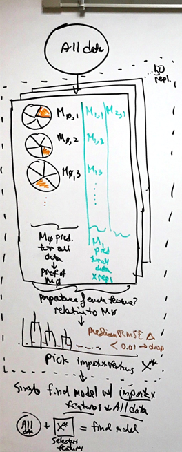

More specifically, we use a "helper function" to specify the criteria by which "important" features will be selected. We define a feature `"i"` as "important" if the median importance score for that feature,

```
ΔRMSE = -RMSE_M0 - (-RMSE_Mi)
```

is greater than or equal to 0.01 (log10 POD).

```python
def select_features(
        importances_for_score, criterion_score, thres):
    '''Get important features based on a single criterion and score.

    Returns
    -------
    list of str
        Names of important features corresponding to the columns.
    '''
    importances = importances_for_score[criterion_score]
    ranked_ordered_features = list(
        importances.quantile(0.5)
        .sort_values(ascending=False)
        .index
    )
    importances = importances[ranked_ordered_features]

    where_important = importances.quantile(0.5) >= thres
    important_features = list(importances.loc[:, where_important])

    return important_features
```

```python
criterion_score = 'neg_root_mean_squared_error'
thres = 0.01
```

```python
%%time

args = (
    criterion_score,
    thres
)

importances_for_score = workflow.select_important_features(
    select_features,
    list(title_for_scoring),
    args=args,
    n_splits=config.N_SPLITS,
    n_repeats_cv=config.N_REPEATS_CV,
    random_state_cv=config.RANDOM_STATE_CV,
    n_repeats_perm=config.N_REPEATS_PERM,
    random_state_perm=config.RANDOM_STATE_PERM
)

for score, frame in importances_for_score.items():
    importances_file = path.join(
        config.WRITE_DIR_RESULTS, 'importances-' + score + '.csv')
    frame.to_csv(importances_file, index=False)
```

```
CPU times: total: 15min 40s
Wall time: 5min 38s
```

### A subset of "important" features has been identified

```python
workflow.X
```

| DTXSID | CATMoS_LD50_pred | WATER_SOLUBILITY_MOL/L_OPERA_PRED | SOIL_ADSORPTION_COEFFICIENT_KOC_L/KG_OPERA_PRED |
| --- | --- | --- | --- |
| DTXSID5020281 | 236.0 | 0.001318 | 507.6930 |
| DTXSID8020961 | 787.0 | 0.004816 | 75.9962 |
| DTXSID7030698 | 9819.0 | 0.389351 | 44.0390 |
| DTXSID2026652 | 2985.0 | 0.000007 | 2084.2800 |
| DTXSID6026080 | 2860.0 | 0.000093 | 30.6322 |
| ... | ... | ... | ... |
| DTXSID3026645 | 2893.0 | 0.000202 | 1947.7600 |
| DTXSID0029133 | 1346.0 | 0.073160 | 53.6562 |
| DTXSID0021832 | 986.0 | 0.005007 | 79.6007 |
| DTXSID6020303 | 233.0 | 5.563510 | 1452.1500 |
| DTXSID5023792 | 1185.0 | 0.003242 | 80.1488 |

1396 rows × 3 columns

```python
# Format the results for plotting: wide to long form, sorted.
importances_for_score = {
    score : importances.melt().sort_values(by='value', ascending=False)
    for score, importances in importances_for_score.items()
}
```

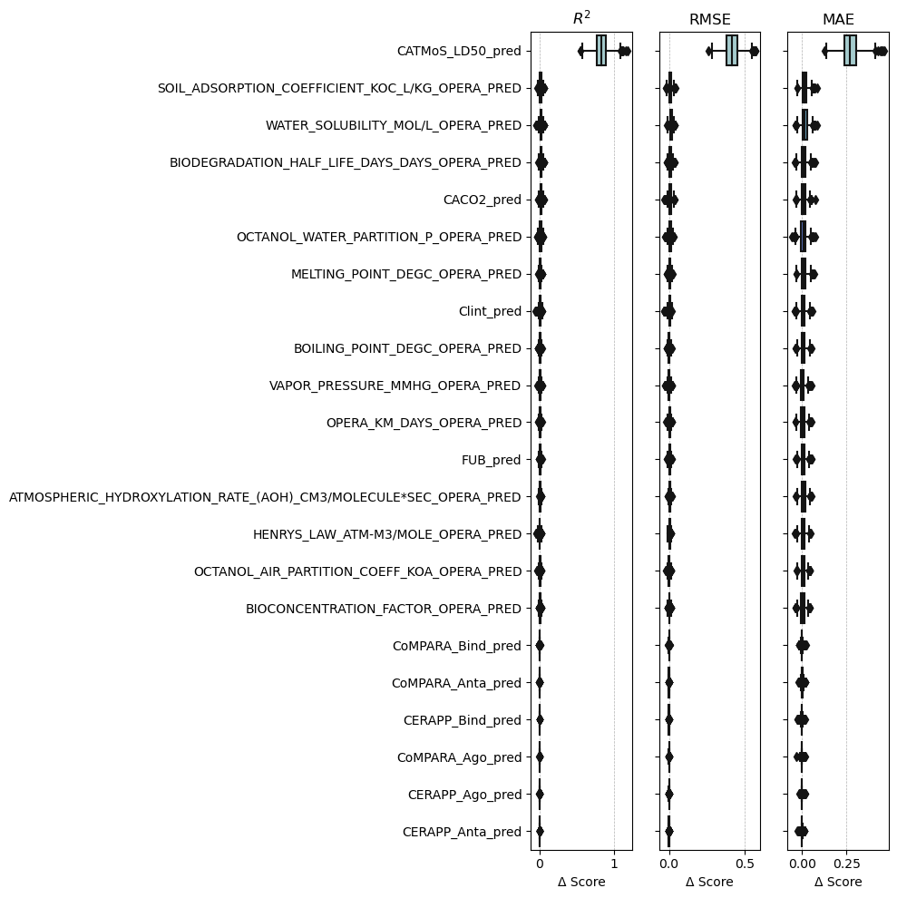

```python
## Define plot parameters.

x = 'value'
y = 'variable'
xlabel = 'Δ Score'
figsize = (10., 10.)
# Define the filename.
suffix = ''
for s in workflow_data_attributes[1:]:
    suffix += s + '-'
estimator_name = type(estimator).__name__
importances_fname = (
    'importances-'
    + estimator_name
    + '-'
    + suffix.strip('-')
)
importances_write_path = path.join(config.WRITE_DIR_FIGURES, importances_fname)

fig, axs = plot.vertical_boxplots(
    importances_for_score,
    x,
    y,
    xlabel,
    title_for_key=title_for_scoring,
    figsize=figsize,
    write_path=importances_write_path,
    palette='icefire'
)
```

## Prepare the "final model"

```python
workflow.fit_to_all_data()  # i.e., X & y
```

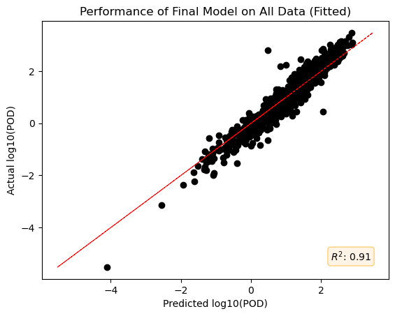

```python
y_pred = workflow.estimator.predict(workflow.X)

score = round(getattr(metrics, 'r2_score')(workflow.y, y_pred), 2)
score_text = '$R^2$: ' + str(score)

_ = plot.bivariate_regression(
    y_pred,
    workflow.y,
    score_text,
    title='Performance of Final Model on All Data (Fitted)',
    xlabel='Predicted log10(POD)',
    ylabel='Actual log10(POD)'
)
```

## Next steps

### 1. Estimate the generalization error

We would like to evaluate the final model's performance on unseen data. However, we do not have an external dataset for evaluation. Dr. Chiu thought of an alternative approach:

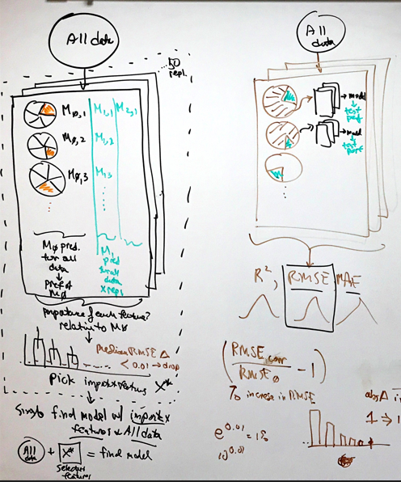

**Question:** If I understand correctly, the goal is to generate an ensemble of "final models" whose features were selected based on data that were unseen during feature selection for the actual "final model." I envision applying the function, `select_important_features`, within a loop to generate this ensemble. However, I am wondering *what exactly should be varying* across the iterations?

#### The parameters

- `select_features`: Explained above
- `random_state_cv`: Controls the randomness of the repeated cross-validation. Presently, using the integer, 1, for reproducibility.
- `n_repeats_cv`: Number of times to repeat the cross-validation. Each repeat shuffles X & y different prior to splitting, as defined by random_state_cv. Presently, 50 repeats.
- `n_splits`: Number of folds for each repeat. Presently, 5.
- `random_state_perm`: Controls the randomness of the permutations of each feature. Presently, using the integer, 1, for reproducibility.
- `n_repeats_perm`: Number of times to permute a feature. Presently, 5.

### 2. Apply to other effect types?

- Oral, reproductive & developmental effects
- Inhalation?